# pedigree_diagnostics

2024-02-22

# Pedigree reconstruction using Sequoia

Pedigree reconstruction was done in two stages - as recommended in the sequoia vignette.

In both stages reconstructed pedigrees were compared to the corrected pedigree (i.e. the one already purged by Alex and Elu, so hopefully shouldn’t be too many mismatches initially!)

1. *Parentage assignment*
- Assigns genotyped parents to genotyped offspring
- Very quick, designed to find some initial errors in the field pedigree
2. *Full reconstruction*
- Creates dummy ids where parent doesnt match offspring and cannot find a match in the database … also useful to find missing links
- Multiple iterations to generate a ML of parentage

# Summary

- Initial parentage assignment showed some ids where genetic sex and recorded sex didnt match i.e. so mother was actually the father
- Some examples of mislabeled ids
- 1 possible extra pair paternity
- 1 id where matched to completely different parents from a few years ago. Could be a pair of ids that were sampled and ringed then left the study area and tags fell off, then re-entered the study area 5 yrs later and were ringed again.(?)
- A few examples of mothers/fathers being mismatched with offspring and have a relatedness O-P of ~0.25 i.e. more like auntie-niece etc. Checked the mothers and many of them come from crossfostered nests, so perhaps a mix up in ids i.e. where sibling was genotyped under the wrong id. But not sure when sampling Vs ringing occurs.

…. Details below

(When i use the terms recorded and hypothesised im referring to the parents recorded in the pedigree vs the parents inferred by sequoia)

# Inital parentage assignment

Only 20 mismatches between the reconstructed pedigree and the original pedigree

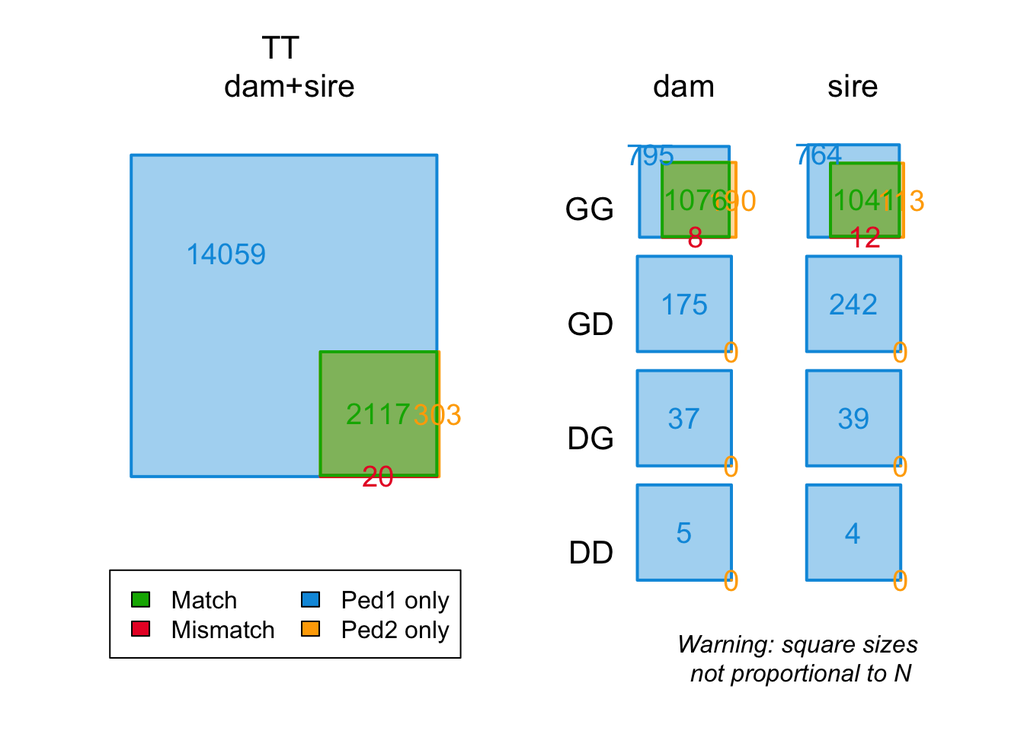

### Most initial mismatches appear to be a mix up in sex or mislabelling

- M026267 and M038112 recorded as female but actually a male according to the genetic sex
- M026658 recorded as male but genetic sex is female
- A potential mislabelling of id ‘M031195’ which is actually ‘M041195’??

**Below shows the flagged mismatches from the comparison:**

- columns dam.1 and sire.1 are the recorded mother and father
- columns dam.2 and sire.2 are the inferred parents from seqouia

```r
mismatch_parents=compare_parentage$Mismatch
print(mismatch_parents)
```

```
##           id   dam.1  sire.1   dam.2  sire.2    id.r dam.r sire.r id.dam.cat
## 332  M010989 M027000 M010971 M022696    <NA> M010989    NA     NA         GG
## 410  M011867 M011634 M011635  871649  870404 M011867    NA     NA         GG
## 613  M026190 M027000 M010971 M022696    <NA> M026190    NA     NA         GG
## 622  M026231 M027000 M010971 M022696    <NA> M026231    NA     NA         GG
## 623  M026232 M027000 M010971 M022696    <NA> M026232    NA     NA         GG
## 757  M026489 M026267 M026658 M026658 M026267 M026489    NA     NA         GG
## 758  M026491 M026267 M026658    <NA> M026267 M026491    NA     NA         GG
## 759  M026492 M026267 M026658 M026658 M026267 M026492    NA     NA         GG
## 760  M026493 M026267 M026658    <NA> M026267 M026493    NA     NA         GG
## 761  M026494 M026267 M026658 M026658 M026267 M026494    NA     NA         GG
## 2328 M040503 M038112 M028912    <NA> M038112 M040503    NA     NA         GG
## 2329 M040505 M038112 M028912    <NA> M038112 M040505    NA     NA         GG
## 2377 M040592 M028977 M043668    <NA> M040587 M040592    NA     NA         GG
## 2406 M040633 M031605 M031195 M031605 M041195 M040633    NA     NA         GG
```

[output cut: 19 more lines]

## Changed these ids and re-run parentage check

## Only 7 parentage mismatches remaining

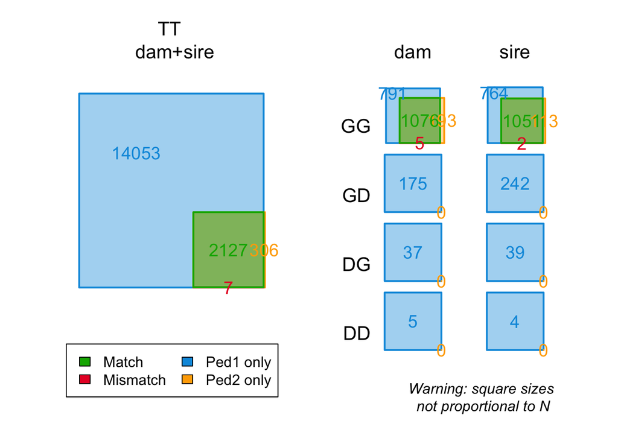

```
##           id   dam.1  sire.1   dam.2  sire.2    id.r dam.r sire.r id.dam.cat
## 332  M010989 M027000 M010971 M022696    <NA> M010989    NA     NA         GG
## 410  M011867 M011634 M011635  871649  870404 M011867    NA     NA         GG
## 613  M026190 M027000 M010971 M022696    <NA> M026190    NA     NA         GG
## 622  M026231 M027000 M010971 M022696    <NA> M026231    NA     NA         GG
## 623  M026232 M027000 M010971 M022696    <NA> M026232    NA     NA         GG
## 2377 M040592 M028977 M043668    <NA> M040587 M040592    NA     NA         GG
##      id.sire.cat dam.class sire.class
## 332           GD  Mismatch     P1only
## 410           GG  Mismatch   Mismatch
## 613           GD  Mismatch     P1only
## 622           GD  Mismatch     P1only
## 623           GD  Mismatch     P1only
## 2377          GG    P1only   Mismatch
```

## Double parent mismatch for id M011867

#### Comparing parental mismatches with GRM

- Recorded parents **are not genotyped** (M011634, M011635)
- High genomic relatedness (~0.5) with suggested parents (871649 and 870404)

```r
GRM['M011867', '871649']
```

```
## [1] 0.4994524
```

```r
GRM['M011867', '870404']
```

```
## [1] 0.4768299
```

### Comparing with database info:

Recorded parents:

```
##     Id Season Nestbox MaleRing FemaleRing CrossFostered
## 1 1027   2008      51  M011635    M011634             0
```

Hypothesised parents

```
##    Id Season Nestbox MaleRing FemaleRing CrossFostered
## 1 448   1998    161C   870404     871649             1
## 2 493   1999    161C   870404     871649             1
## 3 611   2001     78A   870404     871649             1
## 4 683   2002     78A   870404     871649             1
## 5 745   2003     78A   870404     871649             1
```

According to the hatch date and clutch id its clear that the recorded mother and father ID is correct as it matches the clutches they have

ID (M011867) was born in 2008, ~5 years after the hypothesised parents had a clutch.

```
##    RingId           HatchDate BornClutchId HatchClutchId RaisedClutchId
## 1 M011867 17/06/2008 00:00:00         1027          1027           1027
##              RingDate SiteId
## 1 02/07/2008 00:00:00     51
```

Could it be possible that father M011635 = 870404 and mother M011634 = 871649 but came back into the study area 5 years later?? That would mean breeding for >10 years?

M011867 has 3 siblings, none of which have been genotyped (checked but not shown)

```
##    RingId           HatchDate BornClutchId HatchClutchId RaisedClutchId
## 1 M011866 25/06/2008 00:00:00         1027          1027           1027
## 2 M011867 17/06/2008 00:00:00         1027          1027           1027
## 3 M011868 22/06/2008 00:00:00         1027          1027           1027
## 4 M011869 17/06/2008 00:00:00         1027          1027           1027
##              RingDate SiteId
## 1 02/07/2008 00:00:00     51
## 2 02/07/2008 00:00:00     51
## 3 02/07/2008 00:00:00     51
## 4 02/07/2008 00:00:00     51
```

#### >> can we check the photos to see if they look like the same individuals??

## M040592

- Has a mismatched sire

Hypothesised sire has relatedness of 0.467 with offspring, recorded sire not genotyped

```r
print(remaining_mismatch_parents)
```

```
##           id   dam.1  sire.1   dam.2  sire.2    id.r dam.r sire.r id.dam.cat
## 332  M010989 M027000 M010971 M022696    <NA> M010989    NA     NA         GG
## 410  M011867 M011634 M011635  871649  870404 M011867    NA     NA         GG
## 613  M026190 M027000 M010971 M022696    <NA> M026190    NA     NA         GG
## 622  M026231 M027000 M010971 M022696    <NA> M026231    NA     NA         GG
## 623  M026232 M027000 M010971 M022696    <NA> M026232    NA     NA         GG
## 2377 M040592 M028977 M043668    <NA> M040587 M040592    NA     NA         GG
##      id.sire.cat dam.class sire.class
## 332           GD  Mismatch     P1only
## 410           GG  Mismatch   Mismatch
## 613           GD  Mismatch     P1only
## 622           GD  Mismatch     P1only
## 623           GD  Mismatch     P1only
## 2377          GG    P1only   Mismatch
```

```r
#recorded sire
#GRM['M040592', 'M043668'] ##
```

```r
#hypothesised sire
GRM['M040592', 'M040587']
```

```
## [1] 0.4673563
```

Clutches where recorded sire is the father in the database:

```
##     Id Season Nestbox MaleRing FemaleRing CrossFostered
## 1 2005   2019       2  M043668    M028977            NA
## 2 2317   2021       2  M043668    M048274            NA
## 3 2373   2021      3A  M043668    M040995            NA
## 4 2509   2022      3A  M043668    M040832            NA
## 5 2602   2023     306  M043668    M040832            NA
## 6 2671   2023      3B  M043668    M048507            NA
```

Clutches where hypothesised sire is the father in the database:

```
##     Id Season Nestbox MaleRing FemaleRing CrossFostered
## 1 2024   2019    167B  M040587    M040586            NA
## 2 2064   2019    167A  M040587    M040586            NA
## 3 2095   2020    167B  M040587    M038289            NA
## 4 2230   2020    167A  M040587    M040654            NA
## 5 2256   2021    167B  M040587    M048267            NA
## 6 2400   2021    167A  M040587    M048267            NA
## 7 2477   2022    167A  M040587    M048267            NA
```

Id clutch: Born in 2019 so actually overlaps both male seasons

```
##    RingId           HatchDate BornClutchId HatchClutchId RaisedClutchId
## 1 M040592 05/05/2019 00:00:00         2005          2005           2005
##              RingDate SiteId
## 1 21/05/2019 18:32:15      2
```

Other ids in clutch 2005:

```r
life2%>%
  filter(BornClutchId=="2005")
```

```
##    RingId           HatchDate BornClutchId HatchClutchId RaisedClutchId
## 1 M040590 07/05/2019 00:00:00         2005          2005           2005
## 2 M040591 07/05/2019 00:00:00         2005          2005           2005
## 3 M040592 05/05/2019 00:00:00         2005          2005           2005
##              RingDate SiteId
## 1 21/05/2019 18:32:15      2
## 2 21/05/2019 18:32:15      2
## 3 21/05/2019 18:32:15      2
```

Relatedness between hypothesised father and another offsrping in the same clutch

```r
GRM['M040590', 'M040587']
```

```
## [1] 0.4795487
```

A sibling in the clutch has been genotyped as well and also has a very high relatedness with the hypothesised father (0.4795) So potentially the whole clutch has the wrong recorded father. (strange that the sibling didnt come back with an error though, maybe paternal error rates are too high?)

So, clear that the recorded father raised the clutch Could be extra-pair paternity as they occur in very similar season? so M028977 mated with M040587 but M043668 did the raising

#### >> Can we check how far away the 2 nestboxes are: 2 and 167B

```
##           id   dam.1  sire.1   dam.2  sire.2    id.r dam.r sire.r id.dam.cat
## 332  M010989 M027000 M010971 M022696    <NA> M010989    NA     NA         GG
## 410  M011867 M011634 M011635  871649  870404 M011867    NA     NA         GG
## 613  M026190 M027000 M010971 M022696    <NA> M026190    NA     NA         GG
## 622  M026231 M027000 M010971 M022696    <NA> M026231    NA     NA         GG
## 623  M026232 M027000 M010971 M022696    <NA> M026232    NA     NA         GG
## 2377 M040592 M028977 M043668    <NA> M040587 M040592    NA     NA         GG
##      id.sire.cat dam.class sire.class
## 332           GD  Mismatch     P1only
## 410           GG  Mismatch   Mismatch
## 613           GD  Mismatch     P1only
## 622           GD  Mismatch     P1only
## 623           GD  Mismatch     P1only
## 2377          GG    P1only   Mismatch
```

## Dam M027000

- Has many mismatches with her recorded offspring
- But has not been genotyped
- Hypothesised mother (M022696) has high genomic relatedness with all clutch offspring (this is why it was flagged as a mismatch)

```r
GRM['M026190', 'M022696']
```

```
## [1] 0.4752566
```

```r
GRM['M026231', 'M022696']
```

```
## [1] 0.4718399
```

```r
GRM['M026232', 'M022696']
```

```
## [1] 0.4754304
```

```r
GRM['M010989', 'M022696']
```

```
## [1] 0.4748355
```

Recorded mother clutch info:

Has had multiple seasons of offspring

```
##     Id Season Nestbox MaleRing FemaleRing CrossFostered
## 1 1299   2012     449  M010971    M027000             1
## 2 1376   2013     449             M027000             1
## 3 1382   2013     449             M027000             0
```

Hypothesised mother clutch info:

Has not had any offspring according to database

```
## [1] Id            Season        Nestbox       MaleRing      FemaleRing
## [6] CrossFostered
## <0 rows> (or 0-length row.names)
```

Origin clutch of recorded mother:

```
##    RingId           HatchDate BornClutchId HatchClutchId RaisedClutchId
## 1 M027000 13/04/2011 00:00:00         1188          1188           1193
##              RingDate SiteId
## 1 09/06/2011 00:00:00     56
```

Origin clutch of hypothesised mother:

```
##    RingId           HatchDate BornClutchId HatchClutchId RaisedClutchId
## 1 M022696 14/04/2011 00:00:00         1188          1188           1193
##              RingDate SiteId
## 1 09/06/2011 00:00:00     56
```

- Recorded mother and inferred mother are siblings and from the same clutch and moved to the same clutch
- Possibly some sort of mix up between the ids after cross fostering??
- or very high relatedness between auntie and all her nephews/nieces which is kind of unlikely?

# Full reconstruction

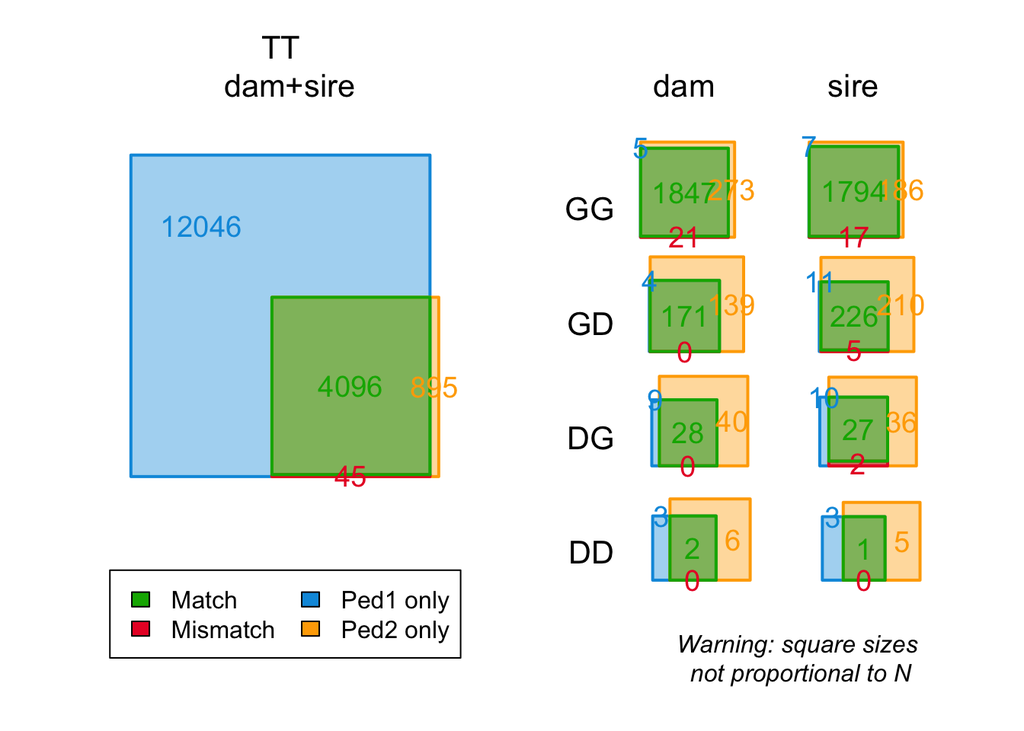

- Removed IDs already discussed
- 36 other examples where parents are mismatched

## Start just with mismatched sires

All ids where the recorded sire is mismatched with offspring i.e. parental genotype doesnt work with offspring genotype

Have all had dummy id’s created as the sires (hence mismatched)

```
##         id   dam.1  sire.1   dam.2 sire.2    id.r dam.r  sire.r id.dam.cat
## 1  M005013  877475  899009    <NA> XM0107 M005013  <NA> nomatch         GG
## 2  M022861 M026459 M006413 M026459 XM0095 M022861  <NA> nomatch         GG
## 3  M022863 M026459 M006413 M026459 XM0095 M022863  <NA> nomatch         GG
## 4  M022864 M026459 M006413 M026459 XM0095 M022864  <NA> nomatch         GG
## 5  M026547 M026459 M006413 M026459 XM0095 M026547  <NA> nomatch         GG
## 6  M026790 M026459 M006413 M026459 XM0095 M026790  <NA> nomatch         GG
## 7  M026792 M026459 M006413 M026459 XM0095 M026792  <NA> nomatch         GG
## 8  M026793 M026459 M006413 M026459 XM0095 M026793  <NA> nomatch         GG
## 9  M026848 M026459 M006413 M026459 XM0095 M026848  <NA> nomatch         GG
## 10 M031661 M033660 M022855 M033660 XM0121 M031661  <NA> nomatch         GG
## 11 M032001 M026459 M006413 M026459 XM0095 M032001  <NA> nomatch         GG
## 12 M032425 M032228 M032203 M032228 XM0123 M032425  <NA> nomatch         GG
## 13 M038183 M031760 M031882 M031760 XM0113 M038183  <NA> nomatch         GG
## 14 M040751 M041177 M040585 M041177 XM0106 M040751  <NA> nomatch         GG
##    id.sire.cat dam.class sire.class
## 1           GG    P1only   Mismatch
## 2           GG     Match   Mismatch
## 3           GG     Match   Mismatch
## 4           GG     Match   Mismatch
## 5           GG     Match   Mismatch
## 6           GG     Match   Mismatch
## 7           GG     Match   Mismatch
## 8           GG     Match   Mismatch
## 9           GG     Match   Mismatch
## 10          GG     Match   Mismatch
## 11          GG     Match   Mismatch
## 12          GG     Match   Mismatch
## 13          GG     Match   Mismatch
## 14          GG     Match   Mismatch
```

## Relatedness between recorded sire and offspring

- Many as expected for parent-offspring so probably incorrect by sequoia / genotyping coverage

```r
GRM['M005013', '899009']
```

```
## [1] 0.5278819
```

```r
GRM['M022861', 'M006413']
```

```
## [1] 0.5291554
```

```r
GRM['M022863', 'M006413']
```

```
## [1] 0.5254648
```

```r
GRM['M022864', 'M006413']
```

```
## [1] 0.5112699
```

```r
GRM['M026547', 'M006413']
```

```
## [1] 0.5253348
```

```r
GRM['M026790', 'M006413']
```

```
## [1] 0.5123388
```

```r
GRM['M026792', 'M006413']
```

```
## [1] 0.5187293
```

```r
GRM['M026793', 'M006413']
```

```
## [1] 0.5087559
```

```r
GRM['M026848', 'M006413']
```

```
## [1] 0.5183488
```

```r
GRM['M031661', 'M022855']
```

```
## [1] 0.5353067
```

```r
GRM['M032001', 'M006413']
```

```
## [1] 0.5133222
```

```r
GRM['M038183', 'M031882']
```

```
## [1] 0.5333804
```

## Only 2 flagged mismatches show quite low relatedness between parent-offspring

- M032425
- M040751

## M032425

Actually M032425 has quite low relatedness with both parents which is weird: (but not super low )

```r
GRM['M032425', 'M032203']
```

```
## [1] 0.3314224
```

```r
GRM['M032425', 'M032228']
```

```
## [1] 0.3442528
```

Details of focal id clutch

```
##    RingId           HatchDate BornClutchId HatchClutchId RaisedClutchId
## 1 M032425 11/06/2015 00:00:00         1463          1463           1465
##              RingDate SiteId
## 1 02/07/2015 00:00:00    189
```

Details of sire clutch:

```
##    RingId           HatchDate BornClutchId HatchClutchId RaisedClutchId
## 1 M032203 23/06/2013 00:00:00         1374          1374           1375
##              RingDate SiteId
## 1 15/07/2013 00:00:00    100
```

Details of mother clutch: (note this wasnt flagged as a mismatch but relatedness was very low so wanted to take a look)

```
##    RingId           HatchDate BornClutchId HatchClutchId RaisedClutchId
## 1 M032228 02/07/2014 00:00:00           NA            NA             NA
##              RingDate SiteId
## 1 17/04/2015 00:00:00     40
```

```r
df_bird%>%
  filter(Id=="1463")

df_bird%>%
  filter(Id=="1465")
```

[output not shown]

## M040751

Relatedness low for parent-offspring

```r
GRM['M040751', 'M040585']
```

```
## [1] 0.2278772
```

Clutch info for focal id

```
##    RingId           HatchDate BornClutchId HatchClutchId RaisedClutchId
## 1 M040751 16/04/2020 00:00:00         2094          2094           2094
##              RingDate SiteId
## 1 11/05/2020 09:43:59    136
```

Clutch info for recorded sire: (no info on born clutch etc so immigrant id)

```
##    RingId HatchDate BornClutchId HatchClutchId RaisedClutchId
## 1 M040585                     NA            NA             NA
##              RingDate SiteId
## 1 20/09/2018 00:00:00     83
```

Double checking nextboxID

```
##     Id Season Nestbox MaleRing FemaleRing CrossFostered
## 1 2094   2020     136  M040585    M041177            NA
```

#### All records look to be correct in the database, so not sure whats going on here!

## Mismatched mothers

```
##         id   dam.1  sire.1  dam.2  sire.2    id.r   dam.r  sire.r id.dam.cat
## 1  M005026  877475  899009 XF0089    <NA> M005026 nomatch    <NA>         GG
## 2  M005473  877475  899009 XF0087    <NA> M005473 nomatch    <NA>         GG
## 3  M026444 M026258 M012595 XF0093 M012595 M026444 nomatch    <NA>         GG
## 4  M026522 M026392 M022673 XF0020 M022673 M026522 nomatch    <NA>         GG
## 5  M026523 M026392 M022673 XF0020 M022673 M026523 nomatch    <NA>         GG
## 6  M026524 M026392 M022673 XF0020 M022673 M026524 nomatch    <NA>         GG
## 7  M026525 M026392 M022673 XF0020 M022673 M026525 nomatch    <NA>         GG
## 8  M026986 M022177 M022673 XF0095 M022673 M026986 nomatch    <NA>         GG
## 9  M032144 M027970 M032251 XF0049 M032251 M032144 nomatch    <NA>         GG
## 10 M032334 M026986 M032218 XF0095  XM0050 M032334 nomatch M032218         GG
## 11 M038154 M022891 M031661 XF0096 M031661 M038154 nomatch    <NA>         GG
## 12 M038379 M032187 M034670 XF0014 M034670 M038379 nomatch    <NA>         GG
## 13 M038381 M032187 M034670 XF0014 M034670 M038381 nomatch    <NA>         GG
## 14 M038382 M032187 M034670 XF0014 M034670 M038382 nomatch    <NA>         GG
```

[output cut: 17 more lines]

All these seem fine (again maybe an error with sequoia/genotyping)

```r
GRM['M005026', '877475']
```

```
## [1] 0.5301841
```

```r
GRM['M005473', '877475']
```

```
## [1] 0.5327947
```

```r
GRM['M026986', 'M022177']
```

```
## [1] 0.4962399
```

```r
GRM['M032144', 'M027970']
```

```
## [1] 0.5172673
```

```r
GRM['M032334', 'M026986']
```

```
## [1] 0.4891254
```

## These are too low for parental relatedness

```r
GRM['M026444', 'M026258']
```

```
## [1] 0.2174526
```

```r
GRM['M026522', 'M026392']
```

```
## [1] 0.2777319
```

```r
GRM['M026523', 'M026392']
```

```
## [1] 0.251306
```

```r
GRM['M026524', 'M026392']
```

```
## [1] 0.2860046
```

```r
GRM['M026525', 'M026392']
```

```
## [1] 0.2849479
```

## M026444

Recorded mother clutch origin info:

```r
life2%>%
  filter(RingId=="M026258")
```

```
##    RingId           HatchDate BornClutchId HatchClutchId RaisedClutchId
## 1 M026258 26/04/2011 00:00:00         1202          1202           1211
##              RingDate SiteId
## 1 09/06/2011 00:00:00    173
```

Recorded mother origin:

```
##    RingId           HatchDate BornClutchId HatchClutchId RaisedClutchId
## 1 M026392 08/08/2011 00:00:00         1224          1224           1200
##              RingDate SiteId
## 1 22/09/2011 00:00:00     79
```

Checking mothers origin clutch

```
##    RingId           HatchDate BornClutchId HatchClutchId RaisedClutchId
## 1 M026201 19/08/2011 00:00:00         1224          1224           1200
## 2 M026202 18/08/2011 00:00:00         1224          1224           1200
## 3 M026391 15/08/2011 00:00:00         1224          1224           1200
## 4 M026392 08/08/2011 00:00:00         1224          1224           1200
## 5 M026393 10/08/2011 00:00:00         1224          1224           1200
## 6 M026394 13/08/2011 00:00:00         1224          1224           1200
##              RingDate SiteId
## 1 02/10/2011 00:00:00     79
## 2 02/10/2011 00:00:00     79
## 3 02/10/2011 00:00:00     79
## 4 22/09/2011 00:00:00     79
## 5 22/09/2011 00:00:00     79
## 6 02/10/2011 00:00:00     79
```

Again mother has been moved, so could she have got mixed up with a sibling?? Mother is ringed >1 month after hatching … is this before or after theyve been moved and sampled etc.? And why is the ring date so different between the siblings in this clutch?

## Checking hypothesis about sibling mismatches

#### ID M026392

example from earlier

```
##    RingId           HatchDate BornClutchId HatchClutchId RaisedClutchId
## 1 M026392 08/08/2011 00:00:00         1224          1224           1200
##              RingDate SiteId
## 1 22/09/2011 00:00:00     79
```

Ringed on 22/09/2011

But has measurements starting at 12/08/2011 Does this mean it was sampled on that date? In which case could the ids have been mixed up??

```
##   BirdId  RingId Mark             RingType RFRingId ClutchId SeasonNumber
## 1   6381 M026392      Swiss Ringing Scheme                NA            0
## 2   6381 M026392      Swiss Ringing Scheme              1200            0
## 3   6381 M026392      Swiss Ringing Scheme              1200            0
## 4   6381 M026392      Swiss Ringing Scheme              1200            0
## 5   6381 M026392      Swiss Ringing Scheme              1200            0
## 6   6381 M026392      Swiss Ringing Scheme                NA            0
## 7   6381 M026392      Swiss Ringing Scheme              1200            0
##       ObservationDate
## 1 22/09/2011 00:00:00
## 2 12/08/2011 22:30:00
## 3 16/08/2011 22:30:00
## 4 22/08/2011 22:30:00
## 5 29/08/2011 10:00:00
## 6 05/09/2011 00:00:15
## 7 05/09/2011 15:15:00
```

### M032203

Another example from above

Same story. Has measurements taken on 2/07/2013 but was ringed on 15/07/2013. So if it was sampled at the same time the first measurement was taken then could have been mixed up with the sibling, which would explain the relatedness of ~0.25 between recorded parent and offspring.

```
##    RingId           HatchDate BornClutchId HatchClutchId RaisedClutchId
## 1 M032203 23/06/2013 00:00:00         1374          1374           1375
##              RingDate SiteId
## 1 15/07/2013 00:00:00    100
```

```
##   BirdId  RingId Mark             RingType RFRingId ClutchId SeasonNumber
## 1   7544 M032203      Swiss Ringing Scheme                NA            0
## 2   7544 M032203      Swiss Ringing Scheme                NA            0
## 3   7544 M032203      Swiss Ringing Scheme              1375            0
## 4   7544 M032203      Swiss Ringing Scheme                NA            0
## 5   7544 M032203      Swiss Ringing Scheme              1375            0
## 6   7544 M032203      Swiss Ringing Scheme                NA            1
## 7   7544 M032203      Swiss Ringing Scheme              1413            1
##       ObservationDate
## 1 15/07/2013 00:00:00
## 2 02/07/2013 00:00:16
## 3 02/07/2013 16:15:00
## 4 07/08/2013 00:00:14
## 5 07/08/2013 14:15:00
## 6 14/08/2014 00:00:11
## 7 14/08/2014 11:00:00
```